# Excercises for Day Two materials

Akos Mate

2019 July

We are using some new datasets for practice. If you are interested in various datasets for practice or personal pet projects, a good starting point is the (Tidy Tuesday)[https://github.com/rfordatascience/tidytuesday] GitHub repo where they post a new dataset each week.

The packages needed for these excercises are:

- `readr`
- `ggplot2`
- `ggridges`
- `dplyr`
- `gapminder`

# 1 Session 5

## 1.1 Excercise 1 - Practicing `ggplot`

> Using the ‘squads’ data, create a scatterplot where the number of caps (international games played) is depicted along the X-axis, goals (international goals scored) is visualized at the Y-axis. Let’s add colors based on the footballer’s position.

More info on the dataset: https://github.com/rfordatascience/tidytuesday/tree/master/data/2019/2019-07-09

```r
squads <- readr::read_csv("https://raw.githubusercontent.com/rfordatascience/tidytuesday/master/data/2019/2019-07-09/squads.csv")
```

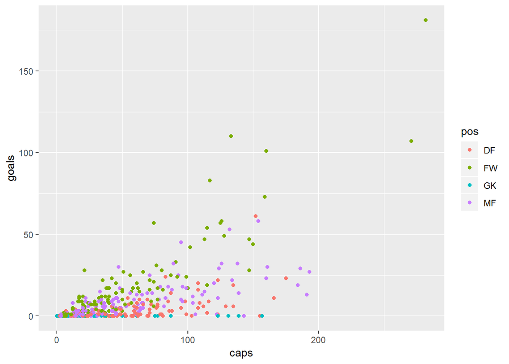

> Now, overlay multiple histograms on each other – use fill = variable to have a histogram of goals with players of different position depicted with different colors. You might want to trim (set the limits of) the x-axis at 75 goals, as very few players score more than that.

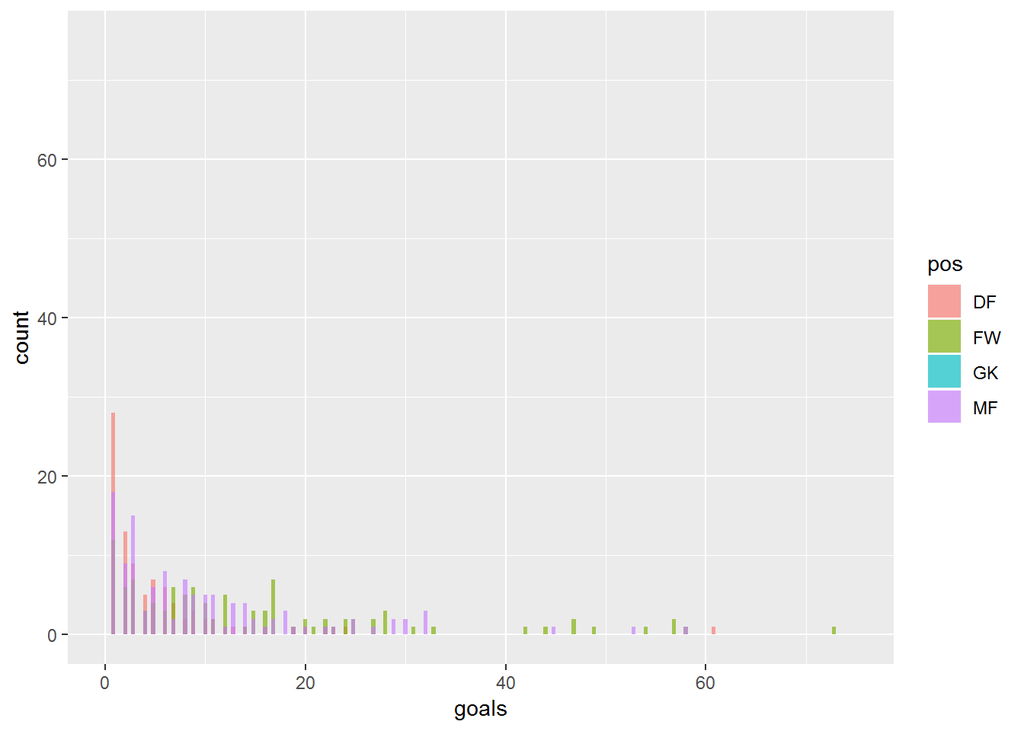

> Create a histogram of caps (international games played), fill the bars with grey color, and overlap it with a density plot, filled with the color ‘salmon’!

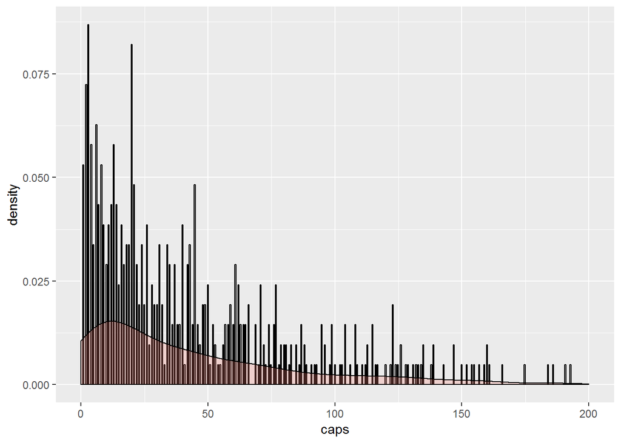

Now we use the other part of the World Cup data.

```r
wwc_outcomes <- readr::read_csv("https://raw.githubusercontent.com/rfordatascience/tidytuesday/master/data/2019/2019-07-09/wwc_outcomes.csv")
```

> Create a joyplot of *scores* using the wwc_outcomes data, using the result (i.e. whether the team won, lost or tied) as a grouping variable!

```r
library(ggridges)
```

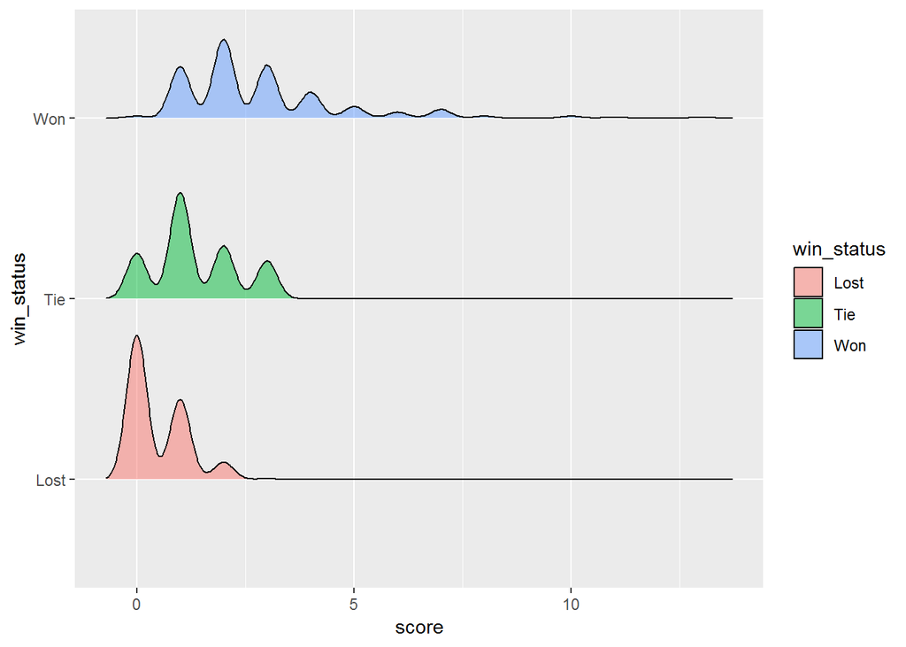

# 2 Session 6

## 2.1 Excercise 2 - Loops

> Excercise: recode gapminder gdp variable to below and above average dummy with a loop. Check the result of the loop!

```r
library(gapminder)

gapminder_df <- gapminder
```

```r
table(gapminder_df$gdp)
```

```
#>
#> above below
#>   534  1170
```

## 2.2 Excercise 3 - Writing functions

> Write a function called `z_score`, which standardizes (creates z scores from raw scores) an input vector. The formula for the standardization is: $z=\frac{x-\bar{x}}{S}$  
> where, $x$ is the raw score (numeric value in our input vector) in our sample; $\bar{x}$ is the sample mean; and $S$ is the sample standard deviation.

Check our function with some random, normally distributed data, and standardize the first 5 value.

```r
height <- rnorm(50, 0, 1)

z_score(height[1:5], height)
```

```
#> [1]  1.0789871381 -0.0710757419 -0.7661889983  0.0038310811 -0.0007920582
```

## 2.3 Excercise 4 - `apply` function

> Select the numerical variables of the `msleep` data and put into a new dataframe called `msleep_num` (explore the `select_if` function!)

```r
library(dplyr)
msleep_df <- msleep
```

```r
glimpse(msleep_num)
```

```
#> Observations: 83
#> Variables: 6
#> $ sleep_total <dbl> 12.1, 17.0, 14.4, 14.9, 4.0, 14.4, 8.7, 7.0, 10.1,...
#> $ sleep_rem   <dbl> NA, 1.8, 2.4, 2.3, 0.7, 2.2, 1.4, NA, 2.9, NA, 0.6...
#> $ sleep_cycle <dbl> NA, NA, NA, 0.1333333, 0.6666667, 0.7666667, 0.383...
#> $ awake       <dbl> 11.9, 7.0, 9.6, 9.1, 20.0, 9.6, 15.3, 17.0, 13.9, ...
#> $ brainwt     <dbl> NA, 0.01550, NA, 0.00029, 0.42300, NA, NA, NA, 0.0...
#> $ bodywt      <dbl> 50.000, 0.480, 1.350, 0.019, 600.000, 3.850, 20.49...
```

> Calculate the column means of the msleep_num data frame. Use the `apply()` function!  
> you should get something similar:

```
#> sleep_total   sleep_rem sleep_cycle       awake     brainwt      bodywt
#>  10.4337349   1.8754098   0.4395833  13.5674699   0.2815814 166.1363494
```

# 3 Session 7

## 3.1 Excercise 5 - t-test

> Load the iris dataset and see if the difference between the petal lenght between the setosa and versicolor are statistically significant or not. Tip: use the previously learned filter() function from dplyr to prep the data. You should get something similar as below. Load the iris data with `data(iris)`. You can turn the scientific notation off with `options(scipen = 999)`.

```
#>
#>  Welch Two Sample t-test
#>
#> data:  Petal.Length by Species
#> t = -27.094, df = 33.102, p-value < 0.00000000000000022
#> alternative hypothesis: true difference in means is not equal to 0
#> 95 percent confidence interval:
#>  -2.962924 -2.549076
#> sample estimates:
#>     mean in group setosa mean in group versicolor
#>                    1.456                    4.212
```

## 3.2 Excercise 6 - ANOVA

> Quick excercise: load the `airquality` data from the `survey` package (with `data(airquality)`) and test with anova if the monthly mean temepratures are significantly different from each other. The temperature is `Temp` and the monhts are `Month`. How would you interpret the result?

```r
data(airquality)
```

```
#>              Df Sum Sq Mean Sq F value       Pr(>F)
#> Month         1   2413  2413.0   32.52 0.0000000603 ***
#> Residuals   151  11205    74.2
#> ---
#> Signif. codes:  0 '***' 0.001 '**' 0.01 '*' 0.05 '.' 0.1 ' ' 1
```

## 3.3 regression

> Using the `gapminder` dataset, filter our observations to the year of 2007 and see what are the effects of the GDP per capita, population and continent on the life expectancy.

The result should be something like this. How would you interpret this?

```r
summary(reg_gap)
```

```
#>
#> Call:
#> lm(formula = lifeExp ~ gdpPercap + pop + continent, data = gap_prep)
#>
#> Residuals:
#>      Min       1Q   Median       3Q      Max
#> -22.8199  -2.8905   0.1574   2.9046  20.0585
#>
#> Coefficients:
#>                    Estimate Std. Error t value Pr(>|t|)
#> (Intercept)       5.371e+01  9.356e-01  57.413  < 2e-16 ***
#> gdpPercap         3.479e-04  5.717e-05   6.086 1.13e-08 ***
#> pop               9.586e-10  3.926e-09   0.244  0.80747
#> continentAmericas 1.603e+01  1.671e+00   9.592  < 2e-16 ***
#> continentAsia     1.256e+01  1.621e+00   7.751 1.97e-12 ***
#> continentEurope   1.520e+01  1.966e+00   7.730 2.20e-12 ***
#> continentOceania  1.662e+01  4.993e+00   3.329  0.00112 **
#> ---
#> Signif. codes:  0 '***' 0.001 '**' 0.01 '*' 0.05 '.' 0.1 ' ' 1
#>
#> Residual standard error: 6.597 on 135 degrees of freedom
#> Multiple R-squared:  0.7141, Adjusted R-squared:  0.7014
#> F-statistic:  56.2 on 6 and 135 DF,  p-value: < 2.2e-16
```